# Basic genetic map construction

Min-Yao Jhu

2021-03-02

## Learning Goals

*At the end of this exercise, you will be able to:* 1. know the concept of F2 intercross and the standard input format for R/qtl 2. summarize and understand the F2 intercross data 3. construct basic genetic map using R/qtl 4. create interactive graphics for genetic mapping using R/qtlcharts

## Resources and references

- [R/qtl: A QTL mapping environment](https://rqtl.org/)
- [R/qtl manual](https://rqtl.org/manual/qtl-manual.pdf)
- [R/qtlcharts Interactive Graphics for Quantitative Trait Locus Mapping](https://www.ncbi.nlm.nih.gov/pmc/articles/PMC4317647/)
- [R/qtlcharts](http://kbroman.org/qtlcharts/)

## F2 intercross strategy

- [Resource](http://www.cdfd.org.in/SILKSAT/F2_cross_strategy.html)

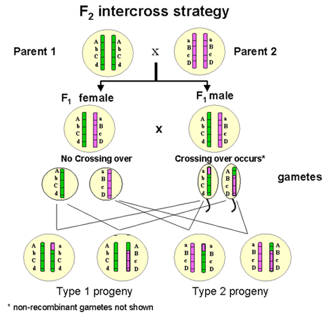

## Load the libraries

```r
library(qtl)
library(qtlcharts)
knitr::opts_chunk$set(fig.width=8, fig.height=6, message=FALSE)
```

The function read.cross is for importing data into R/qtl.

```r
#?read.cross
```

## Example 1: Identify genomic regions that regulate blood pressure, heart rate, and heart weight

We will consider data from [Sugiyama et al., Physiol Genomics 10:5–12, 2002](https://journals.physiology.org/doi/full/10.1152/physiolgenomics.00002.2002). The data are from an intercross between BALB/cJ and CBA/CaJ; only male offspring were considered. There are four phenotypes: blood pressure, heart rate, body weight, and heart weight. “sug.csv” is the name of the file, which we import directly from the R/qtl website. genotypes indicates the codes used for the genotypes; alleles indicates single-character codes to be used in plots and such.

```r
sug <- read.cross("csv", "https://rqtl.org", "sug.csv",
                  genotypes=c("CC", "CB", "BB"), alleles=c("C", "B")) #Specifying genotype you have
```

```
##  --Read the following data:
##   163  individuals
##   93  markers
##   6  phenotypes
##  --Cross type: f2
```

## Summaries

Get a quick summary of the data.

```r
summary(sug)
```

```
##     F2 intercross
##
##     No. individuals:    163
##
##     No. phenotypes:     6
##     Percent phenotyped: 95.1 95.7 99.4 99.4 100 100
##
##     No. chromosomes:    19
##         Autosomes:      1 2 3 4 5 6 7 8 9 10 11 12 13 14 15 16 17 18 19
##
##     Total markers:      93
##     No. markers:        5 7 5 5 5 4 8 4 4 5 6 3 3 5 5 4 4 6 5
##     Percent genotyped:  98.3
##     Genotypes (%):      CC:23.9  CB:50.2  BB:26.0  not BB:0.0  not CC:0.0
```

```r
head(sug$pheno)
```

```
##    bp  hr   bw heart_wt sex mouse_ID
## 1 104 517 37.0      133   1        3
## 2 108 690 38.9      135   1        4
## 3 115 653 43.8      159   1        5
## 4 119 592 42.5      131   1        6
## 5  NA  NA 43.6      128   1        8
## 6 106 517 35.3      175   1        9
```

```r
#Also specifies ID of mouse. so counts as phenotype
#Have sex, but all mice are male, hence why it's 1
#Quantitative traits: bp, hr, bw, heart_wt
```

There are a number of simple functions for pulling out pieces of summary information.

```r
nind(sug)    # No. individuals
```

```
## [1] 163
```

```r
nphe(sug)    # No. phenotypes
```

```
## [1] 6
```

```r
nchr(sug)    # No. chromosomes
```

```
## [1] 19
```

```r
totmar(sug)  # Total markers
```

```
## [1] 93
```

```r
nmar(sug)    # No. markers on each chromosome
```

```
##  1  2  3  4  5  6  7  8  9 10 11 12 13 14 15 16 17 18 19
##  5  7  5  5  5  4  8  4  4  5  6  3  3  5  5  4  4  6  5
```

Get a summary plot of the data.

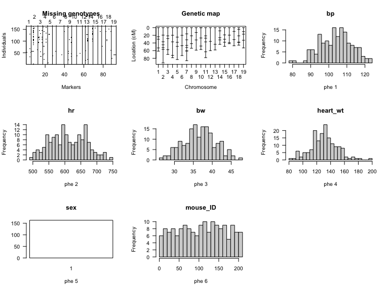

```r
plot(sug)
```

Individual parts of the above plot may be obtained as follows.

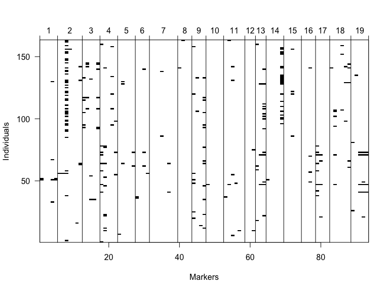

```r
#?plotMissing
#Indicates it finds the missing data on the plot
plotMissing(sug, main="")
```

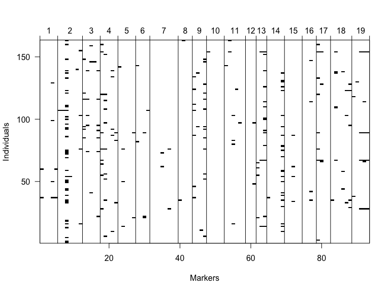

```r
plotMissing(sug, main="", reorder=1)
```

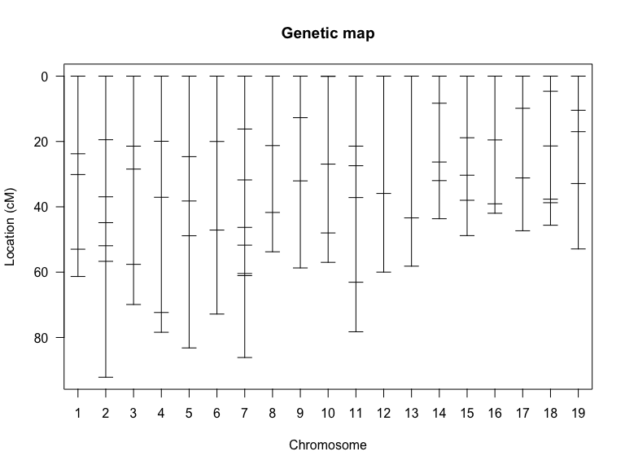

```r
#?plotMap
plotMap(sug)
```

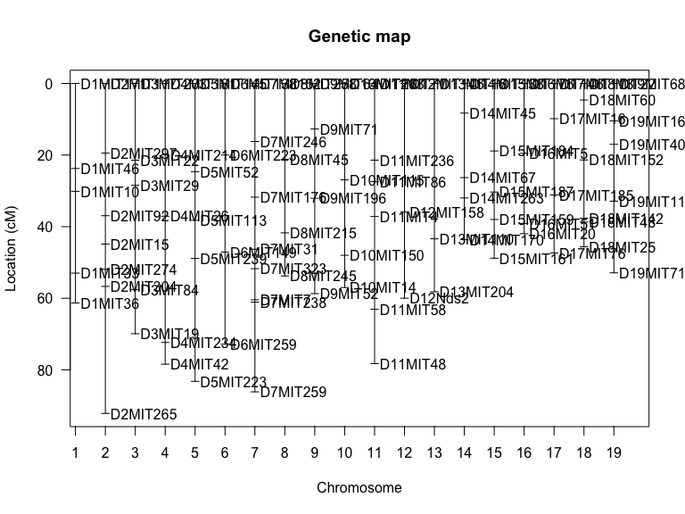

```r
plotMap(sug,show.marker.names=TRUE)
```

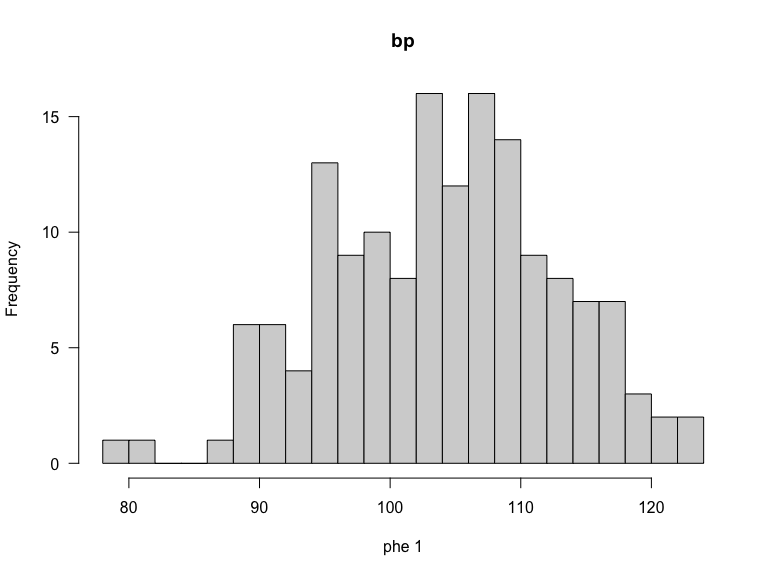

```r
#?plotPheno
plotPheno(sug, pheno.col=1)
```

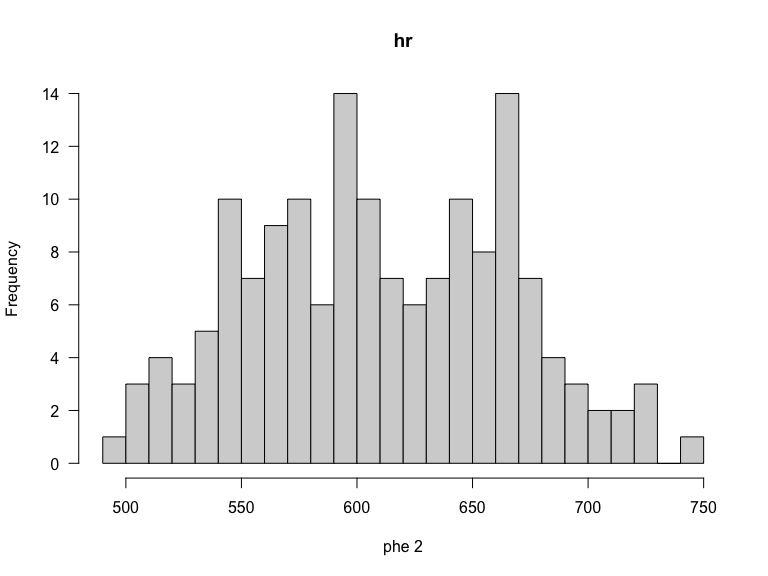

```r
plotPheno(sug, pheno.col=2)
```

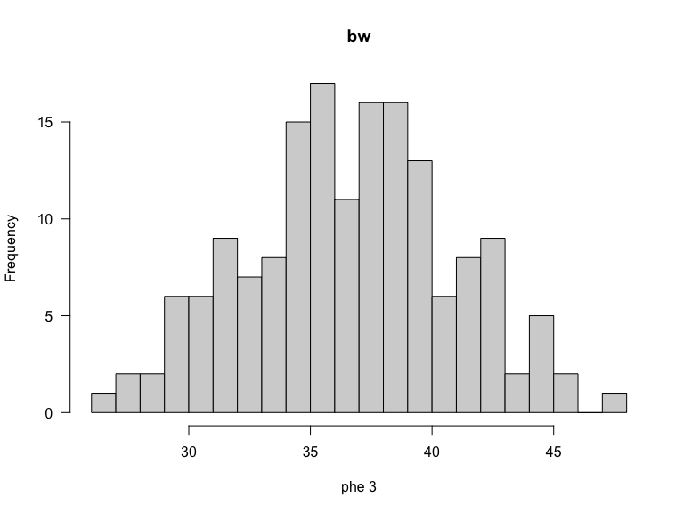

```r
plotPheno(sug, pheno.col=3)
```

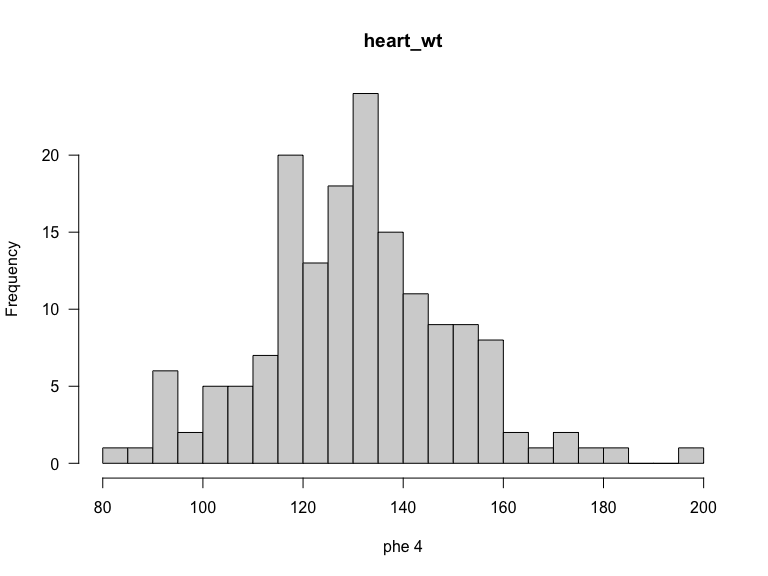

```r
plotPheno(sug, pheno.col=4)
```

Let’s make an interactive chart of the genetic map of markers for these data using R/qtlcharts.

```r
iplotMap(sug) #D7MIT31
```

[interactive chart not shown]

Let’s use iplotCorr to plot a heat map of the correlation matrix for the phenotype of all pairs, linked to scatterplots of the phenotypes.

```r
iplotCorr(sug$pheno)
```

[interactive chart not shown]

```r
iplotCorr(sug$pheno, chartOpts=list(height=300, width=600, scatcolors="pink"))
```

[interactive chart not shown]

The interactive graphs produced by R/qtlcharts are, by default, saved to a temporary file and then opened in the default web browser. If you want to save a chart to a particular file, assign the result to some object and use the function `saveWidget()` in the [htmlwidgets package] (http://www.htmlwidgets.org/), as follows:

```r
corrplot <- iplotCorr(sug$pheno, chartOpts=list(height=300, width=600, scatcolors="pink"))
htmlwidgets::saveWidget(corrplot, file="iplotCorr_example.html")
```

## Quantitative Trait Locus (QTL) Analysis

Quantitative trait locus (QTL) analysis is a statistical method that links two types of information—phenotypic data (trait measurements) and genotypic data (usually molecular markers)—in an attempt to explain the genetic basis of variation in complex traits (Falconer & Mackay, 1996; Kearsey, 1998; Lynch & Walsh, 1998). [Quantitative Trait Locus (QTL) Analysis](https://www.nature.com/scitable/topicpage/quantitative-trait-locus-qtl-analysis-53904/)

### LOD Score

LOD score is actually an acronym for “log of the odds,” LOD. LOD score actually refers to a numerical result when estimating whether two genes, or a gene and a disease, are linked to one another. [NIH LOD Score](https://www.genome.gov/genetics-glossary/LOD-Score#:~:text=LOD%20stands%20for%20%22logarithm%20of,therefore%20likely%20to%20be%20inherited.)

### Single-QTL analysis

We first calculate the QTL genotype probabilities, given the observed marker data, via the function calc.genoprob. This is done at the markers and at a grid along the chromosomes. The argument step is the density of the grid (in cM), and defines the density of later QTL analyses. To perform a single-QTL genome scan, we use the function scanone. By default, it considers the first phenotype in the input cross object (in this case, blood pressure).

```r
sug <- calc.genoprob(sug, step=1) #Indicates density used for calculation, or centimorgan
out.em <- scanone(sug)
out.em2 <- scanone(sug, pheno.col=1:4)
#Dropping phenotypes, so when assessing differences, it will use the first phenotype (ex. in this case blood pressure)
```

The output has “class” “scanone”. The summary function is passed to the function summary.scanone, and gives the maximum LOD score on each chromosome.

```r
summary(out.em)
```

```
##           chr   pos   lod
## D1MIT36     1 76.73 1.449
## c2.loc77    2 82.80 1.901
## c3.loc42    3 52.82 1.393
## c4.loc43    4 47.23 0.795
## D5MIT223    5 86.57 1.312
## c6.loc26    6 27.81 0.638
## c7.loc45    7 47.71 6.109
## c8.loc34    8 54.90 1.598
## D9MIT71     9 27.07 0.769
## c10.loc51  10 60.75 0.959
## c11.loc34  11 38.70 2.157
## D12MIT145  12  2.23 1.472
## c13.loc20  13 27.26 1.119
## D14MIT138  14 12.52 1.119
## c15.loc8   15 11.96 5.257
## c16.loc31  16 45.69 0.647
## D17MIT16   17 17.98 1.241
## D18MIT22   18 13.41 1.739
## D19MIT71   19 56.28 0.402
```

```r
summary(out.em2)
```

```
##           chr   pos    bp     hr     bw heart_wt
## D1MIT36     1 76.73 1.449 0.9306 0.8418  1.10701
## c2.loc77    2 82.80 1.901 3.2352 0.7491  0.14570
## c3.loc42    3 52.82 1.393 0.0199 1.7099  0.22918
## c4.loc43    4 47.23 0.795 0.9465 0.5097  0.40329
## D5MIT223    5 86.57 1.312 0.1639 1.1748  0.05581
## c6.loc26    6 27.81 0.638 0.0762 0.7033  0.15187
## c7.loc45    7 47.71 6.109 0.2060 0.5209  0.47587
## c8.loc34    8 54.90 1.598 0.3938 0.1101  1.50973
## D9MIT71     9 27.07 0.769 0.4386 0.0748  0.07482
## c10.loc51  10 60.75 0.959 0.9614 0.3983  2.60545
## c11.loc34  11 38.70 2.157 1.1985 0.5037  0.00473
## D12MIT145  12  2.23 1.472 0.3669 1.1148  0.66280
## c13.loc20  13 27.26 1.119 0.5487 0.0562  0.29918
## D14MIT138  14 12.52 1.119 0.0612 0.1672  1.39513
## c15.loc8   15 11.96 5.257 1.6771 5.6325  1.26297
## c16.loc31  16 45.69 0.647 0.4475 2.3418  0.07920
## D17MIT16   17 17.98 1.241 1.1660 0.0712  0.74646
## D18MIT22   18 13.41 1.739 0.9585 0.3425  1.39105
## D19MIT71   19 56.28 0.402 0.3015 0.0136  0.25134
```

Alternatively, we can give a threshold, e.g., to only see those chromosomes with LOD > 3.

```r
summary(out.em, threshold=3)
```

```
##          chr  pos  lod
## c7.loc45   7 47.7 6.11
## c15.loc8  15 12.0 5.26
```

We can plot the results as follows.

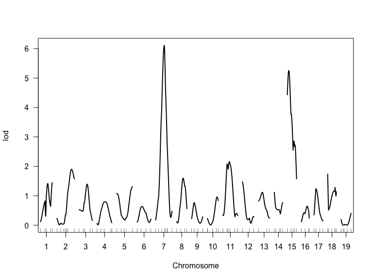

```r
plot(out.em)
```

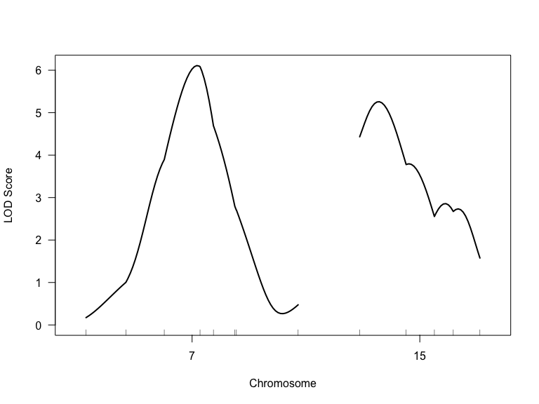

```r
plot(out.em, chr=c(7,15), ylab="LOD Score")
```

### iplotScanone iplotScanone creates an interactive chart with LOD curves from a genome scan linked to estimated QTL effects. If you provide just the output from scanone, the only interactivity is that hovering over marker positions on the LOD curves will give information about the marker name, position, and LOD score.

```r
iplotScanone(out.em)
```

[interactive chart not shown]

You can use the chr to plot only selected chromosomes.

```r
iplotScanone(out.em, chr=c(7,15))
```

[interactive chart not shown]

```r
iplotScanone(out.em, sug)
```

[interactive chart not shown]

```r
#Lets you click on specific phenotype
```

```r
iplotScanone(out.em, sug, chr=c(7,15)) #Limiting scan of to chromosome 7 and 15
```

[interactive chart not shown]

## Example 2: Gravitropism in Arabidopsis

We’ll consider the grav dataset included with R/qtlcharts. These are data from [Moore et al. Genetics 195:1077-1086, 2013](https://doi.org/10.1534/genetics.113.153346), on a QTL experiment on gravitropism in Arabidopsis, with data on 162 recombinant inbred lines (Ler × Cvi). Seedlings were sprouted and then rotated 90 degrees with respect to gravity; the growth of the seedlings was then recorded on video. The outcome is the root tip angle (in degrees) at two-minute increments over eight hours.

```r
data(grav)
```

## Practice

1. Get a quick summary of the grav data.
2. Make an genetic map of markers for the grav data.
3. Plot a heat map of the correlation matrix for the phenotype at all pairs of times, linked to scatterplots of the phenotypes.

## iplotCurves

iplotCurves creates a plot of a set of curves linked to one or two scatterplots.

```r
iplotCurves(grav$pheno)
```

[interactive chart not shown]

```r
times1 <- as.numeric(sub("T", "", phenames(grav)))/60
times1
```

```
##   [1] 0.00000000 0.03333333 0.06666667 0.10000000 0.13333333 0.16666667
##   [7] 0.20000000 0.23333333 0.26666667 0.30000000 0.33333333 0.36666667
##  [13] 0.40000000 0.43333333 0.46666667 0.50000000 0.53333333 0.56666667
##  [19] 0.60000000 0.63333333 0.66666667 0.70000000 0.73333333 0.76666667
##  [25] 0.80000000 0.83333333 0.86666667 0.90000000 0.93333333 0.96666667
##  [31] 1.00000000 1.03333333 1.06666667 1.10000000 1.13333333 1.16666667
##  [37] 1.20000000 1.23333333 1.26666667 1.30000000 1.33333333 1.36666667
##  [43] 1.40000000 1.43333333 1.46666667 1.50000000 1.53333333 1.56666667
##  [49] 1.60000000 1.63333333 1.66666667 1.70000000 1.73333333 1.76666667
##  [55] 1.80000000 1.83333333 1.86666667 1.90000000 1.93333333 1.96666667
##  [61] 2.00000000 2.03333333 2.06666667 2.10000000 2.13333333 2.16666667
##  [67] 2.20000000 2.23333333 2.26666667 2.30000000 2.33333333 2.36666667
##  [73] 2.40000000 2.43333333 2.46666667 2.50000000 2.53333333 2.56666667
##  [79] 2.60000000 2.63333333 2.66666667 2.70000000 2.73333333 2.76666667
##  [85] 2.80000000 2.83333333 2.86666667 2.90000000 2.93333333 2.96666667
```

[output cut: 26 more lines]

```r
times <- attr(grav, "time")
times
```

```
##   [1] 0.00000000 0.03333333 0.06666667 0.10000000 0.13333333 0.16666667
##   [7] 0.20000000 0.23333333 0.26666667 0.30000000 0.33333333 0.36666667
##  [13] 0.40000000 0.43333333 0.46666667 0.50000000 0.53333333 0.56666667
##  [19] 0.60000000 0.63333333 0.66666667 0.70000000 0.73333333 0.76666667
##  [25] 0.80000000 0.83333333 0.86666667 0.90000000 0.93333333 0.96666667
##  [31] 1.00000000 1.03333333 1.06666667 1.10000000 1.13333333 1.16666667
##  [37] 1.20000000 1.23333333 1.26666667 1.30000000 1.33333333 1.36666667
##  [43] 1.40000000 1.43333333 1.46666667 1.50000000 1.53333333 1.56666667
##  [49] 1.60000000 1.63333333 1.66666667 1.70000000 1.73333333 1.76666667
##  [55] 1.80000000 1.83333333 1.86666667 1.90000000 1.93333333 1.96666667
##  [61] 2.00000000 2.03333333 2.06666667 2.10000000 2.13333333 2.16666667
##  [67] 2.20000000 2.23333333 2.26666667 2.30000000 2.33333333 2.36666667
##  [73] 2.40000000 2.43333333 2.46666667 2.50000000 2.53333333 2.56666667
##  [79] 2.60000000 2.63333333 2.66666667 2.70000000 2.73333333 2.76666667
##  [85] 2.80000000 2.83333333 2.86666667 2.90000000 2.93333333 2.96666667
```

[output cut: 26 more lines]

```r
#?attr
phe <- grav$pheno
head(phe)
```

```
##         T0       T2       T4       T6       T8      T10      T12      T14
## 1  -3.4717  -3.2973  -3.4837  -3.8324  -3.9971  -4.4138  -4.6477  -4.9400
## 2  -3.9243  -4.1068  -4.0559  -4.1955  -4.2935  -4.5356  -4.9223  -5.2457
## 3  -7.4022  -7.4470  -7.6809  -7.7515  -8.2363  -8.7546  -9.1621  -9.9663
## 4 -11.0550 -11.0470 -11.1190 -10.8650 -10.9140 -11.2740 -11.2450 -11.2770
## 5  -5.0697  -5.1864  -5.0430  -5.4597  -5.8597  -6.3028  -7.1255  -7.4619
## 6   5.1926   5.3676   5.1018   4.8896   3.9455   3.4340   2.5305   1.8841
##        T16       T18      T20      T22      T24      T26      T28      T30
## 1  -5.4629  -5.89310  -6.5397  -6.9486  -7.7236  -8.3297  -8.9201  -9.6447
## 2  -5.5971  -5.89990  -6.1434  -6.6733  -6.9014  -7.5466  -8.0077  -8.3959
## 3 -10.2640 -10.84700 -11.8350 -12.3950 -13.1180 -13.7720 -14.6950 -15.5160
## 4 -11.2500 -11.58300 -11.6780 -11.7850 -12.1060 -12.3240 -12.7620 -13.1980
## 5  -8.3286  -8.80330  -9.7265 -10.7910 -11.7790 -12.3320 -13.4920 -14.5850
## 6   1.1394   0.12565  -0.7945  -1.5589  -2.3704  -3.5434  -4.5057  -5.5834
##        T32      T34      T36      T38     T40     T42     T44     T46     T48
```

[output cut: 188 more lines]

```r
iplotCurves(phe, times)
```

[interactive chart not shown]

To change the axis labels, pass curves_xlab and curves_ylab using chartOpts.

```r
iplotCurves(phe, times, chartOpts=list(curves_xlab="Time (hrs)",
                                       curves_ylab="Response"))
```

[interactive chart not shown]

```r
iplotCurves(phe, times, phe[,c("T30", "T240")], phe[,c("T240", "T480")],
            chartOpts=list(curves_xlab="Time", curves_ylab="Root tip angle",
                           scat1_xlab="Angle at 30 min", scat1_ylab="Angle at 4 hrs",
                           scat2_xlab="Angle at 4 hrs", scat2_ylab="Angle at 8 hrs"))
```

[interactive chart not shown]

Let’s further run a single-QTL genome scan with each individual time point.

```r
grav <- calc.genoprob(grav, step=1)
out.em <- scanone(grav, pheno.col=1:nphe(grav))
summary(out.em)
```

```
##                chr  pos    T0    T2    T4    T6    T8   T10   T12   T14   T16
## c1.loc44         1 44.0 1.780 1.822 1.842 1.712 1.628 1.610 1.464 1.371 1.242
## Erecta           2 42.7 0.813 0.804 0.871 0.843 0.829 0.844 0.847 0.821 0.834
## GB.97L-Col/99C   3 76.1 3.304 3.249 3.270 3.367 3.438 3.503 3.558 3.663 3.776
## g4539            4 40.3 2.578 2.636 2.674 2.768 2.851 3.014 3.130 3.175 3.324
## c5.loc29         5 29.0 1.710 1.644 1.651 1.688 1.693 1.703 1.673 1.696 1.668
##                  T18  T20   T22   T24   T26   T28   T30   T32   T34   T36   T38
## c1.loc44       1.186 1.13 1.044 0.964 0.908 0.816 0.782 0.666 0.618 0.555 0.507
## Erecta         0.829 0.81 0.801 0.794 0.725 0.701 0.685 0.656 0.624 0.584 0.559
## GB.97L-Col/99C 3.789 3.78 3.813 3.879 3.927 3.939 4.021 4.066 4.067 4.083 4.089
## g4539          3.539 3.65 3.803 3.906 4.175 4.358 4.442 4.594 4.755 4.732 4.852
## c5.loc29       1.671 1.68 1.659 1.673 1.668 1.694 1.673 1.621 1.588 1.612 1.551
##                  T40   T42   T44   T46   T48   T50   T52   T54   T56   T58
## c1.loc44       0.453 0.377 0.368 0.319 0.299 0.279 0.252 0.211 0.192 0.173
## Erecta         0.530 0.508 0.456 0.412 0.411 0.391 0.359 0.324 0.329 0.285
## GB.97L-Col/99C 4.093 4.021 4.003 3.966 3.925 3.788 3.786 3.650 3.591 3.432
## g4539          4.993 5.078 5.148 5.194 5.205 5.207 5.206 5.191 5.284 5.196
## c5.loc29       1.523 1.478 1.442 1.403 1.351 1.299 1.284 1.234 1.161 1.088
##                  T60   T62   T64   T66   T68   T70   T72   T74   T76    T78
## c1.loc44       0.162 0.144 0.129 0.130 0.120 0.106 0.113 0.102 0.101 0.0982
## Erecta         0.290 0.255 0.241 0.230 0.217 0.214 0.206 0.175 0.163 0.1508
## GB.97L-Col/99C 3.339 3.194 3.073 2.917 2.786 2.737 2.567 2.479 2.342 2.2106
## g4539          5.157 5.250 5.222 5.133 5.070 5.027 4.992 4.919 4.853 4.8570
## c5.loc29       1.074 1.042 1.018 0.966 0.922 0.874 0.847 0.814 0.773 0.7299
##                  T80   T82   T84   T86   T88   T90    T92    T94    T96    T98
## c1.loc44       0.103 0.104 0.105 0.098 0.114 0.105 0.1074 0.1172 0.1093 0.1131
## Erecta         0.148 0.132 0.121 0.127 0.119 0.102 0.0914 0.0814 0.0728 0.0601
## GB.97L-Col/99C 2.107 2.005 1.910 1.759 1.686 1.653 1.5581 1.4445 1.3915 1.3201
## g4539          4.708 4.680 4.654 4.628 4.556 4.553 4.4591 4.4817 4.3949 4.3519
## c5.loc29       0.698 0.688 0.652 0.592 0.558 0.566 0.4952 0.5057 0.4541 0.4501
##                 T100   T102   T104   T106   T108   T110  T112   T114   T116
## c1.loc44       0.113 0.1161 0.1200 0.1162 0.1222 0.1318 0.120 0.1385 0.1412
## Erecta         0.054 0.0475 0.0378 0.0359 0.0314 0.0244 0.020 0.0152 0.0156
## GB.97L-Col/99C 1.261 1.2025 1.1539 1.0763 1.0138 0.9615 0.911 0.8466 0.8023
## g4539          4.293 4.1805 4.1896 4.1700 4.0484 4.0468 4.015 3.9296 3.9327
## c5.loc29       0.437 0.4027 0.3911 0.3671 0.3425 0.3148 0.315 0.2957 0.2773
##                  T118  T120    T122    T124    T126    T128    T130    T132
## c1.loc44       0.1360 0.152 0.15143 0.15900 0.17063 0.17645 0.17927 0.18166
## Erecta         0.0111 0.012 0.00674 0.00573 0.00458 0.00189 0.00255 0.00135
## GB.97L-Col/99C 0.7444 0.716 0.65531 0.63656 0.60478 0.54165 0.50956 0.49153
```

[output cut: 107 more lines]

```
## GB.97L-Col/99C 0.217 0.218 0.217 0.218 0.219 0.207 0.212 0.223 0.207 0.214
## g4539          0.831 0.831 0.801 0.767 0.773 0.770 0.737 0.719 0.689 0.697
## c5.loc29       0.402 0.365 0.369 0.358 0.330 0.339 0.316 0.307 0.310 0.297
##                 T446  T448  T450  T452  T454  T456  T458  T460  T462  T464
## c1.loc44       0.237 0.229 0.216 0.212 0.197 0.204 0.198 0.200 0.183 0.192
## Erecta         0.265 0.245 0.259 0.260 0.255 0.242 0.239 0.241 0.240 0.241
## GB.97L-Col/99C 0.226 0.223 0.221 0.217 0.224 0.216 0.222 0.220 0.217 0.217
## g4539          0.674 0.661 0.623 0.625 0.599 0.570 0.547 0.547 0.503 0.471
## c5.loc29       0.289 0.289 0.283 0.270 0.256 0.254 0.260 0.247 0.250 0.251
##                 T466  T468  T470  T472  T474  T476  T478  T480
## c1.loc44       0.190 0.177 0.180 0.171 0.152 0.160 0.154 0.140
## Erecta         0.243 0.230 0.233 0.235 0.212 0.225 0.227 0.218
## GB.97L-Col/99C 0.210 0.216 0.211 0.220 0.203 0.205 0.210 0.214
## g4539          0.455 0.452 0.410 0.417 0.392 0.367 0.353 0.353
## c5.loc29       0.248 0.237 0.244 0.236 0.218 0.229 0.202 0.213
```

## Charts within a loop

If you want to produce multiple interactive charts within a loop.

```r
times_m <- c("T30", "T240", "T480")
times_clear <- c("30 mins", "4 hours", "8 hours")
times_number <- match(times_m, phenames(grav))

for(i in 1:length(times_m))
    print(iplotScanone(out.em, lodcolumn=times_number[i], chartOpts=list(title=times_clear[i])))
```

## That’s it, let’s take a break!

–>[Home](https://jmledford3115.github.io/datascibiol/)